# Building up and evaluating models

# The Agenda

1. Specifying Models
   1. The Random Effects Structure
   2. The Fixed Effects Structure
2. Evaluating and comparing models
   1. Where are the precious p-values!?
   2. Likelihood Ratio Tests
   3. Bootstrap confidence intervals

You’ll also need to have installed a package called `boot` for some parts of this lecture to work.

# Specifying models

Let’s quickly re-review the broad-strokes facts in the /ay/ data.

```r
ay <- ay %>%
        mutate(dob = year-age,
               decade = (dob-1900)/10,
               log2dur = log2(dur),
               dur_c = log2dur - median(log2dur))
```

First, there seems to be some relationship between duration and F1:

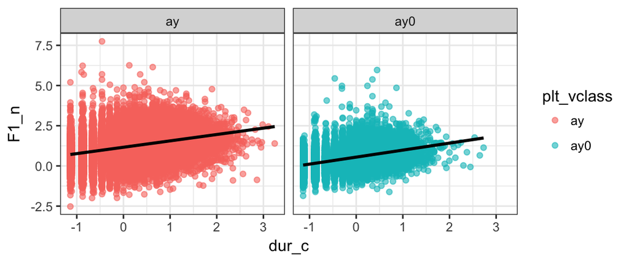

```r
ay %>%
  ggplot(aes(dur_c, F1_n, color = plt_vclass))+
    geom_point(alpha = 0.6)+
    facet_wrap(~plt_vclass)+
    stat_smooth(method = lm,
                color = "black")+
    theme_bw()
```

And there seems to be a relationship between decade and F1

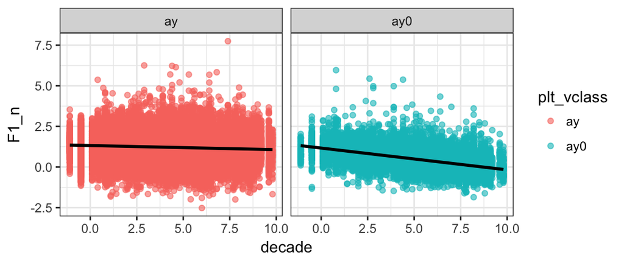

```r
ay %>%
  ggplot(aes(decade, F1_n, color = plt_vclass))+
    geom_point(alpha = 0.6)+
    facet_wrap(~plt_vclass)+
    stat_smooth(method = lm,
                color = "black")+
    theme_bw()
```

There are a number of open questions we are faced with when we approach this data from a modelling perspective:

1. How do we decide which predictors to include in the model?
2. How do we decide *how* they should be included in the model? Which predictorsshould we estimate interactions for?
3. What should the random effects structure be?

To start trying to answer these questions, we need to start talking about *model comparison*. Let’s start by fitting a fairly complex model.

```r
ay_big_mod <- lmer(F1_n ~ decade * dur_c * plt_vclass +
                      (1 + dur_c * plt_vclass | idstring) +
                      (1 | word),
                    data = ay,
                    verbose = T)
```

```r
summary(ay_big_mod)
```

```
Linear mixed model fit by REML ['lmerMod']
Formula: F1_n ~ decade * dur_c * plt_vclass + (1 + dur_c * plt_vclass |      idstring) + (1 | word)
   Data: ay

REML criterion at convergence: 152857.8

Scaled residuals:
    Min      1Q  Median      3Q     Max
-5.6137 -0.5845 -0.0177  0.5643 11.5877

Random effects:
 Groups   Name                Variance Std.Dev. Corr
 word     (Intercept)         0.04092  0.2023
 idstring (Intercept)         0.01600  0.1265
          dur_c               0.01869  0.1367   -0.08
          plt_vclassay0       0.03693  0.1922   -0.58  0.03
          dur_c:plt_vclassay0 0.01365  0.1168    0.27 -0.75  0.09
 Residual                     0.34582  0.5881
Number of obs: 84713, groups:  word, 959; idstring, 326

Fixed effects:
                            Estimate Std. Error t value
(Intercept)                 1.271174   0.021136   60.14
decade                     -0.015488   0.003354   -4.62
dur_c                       0.302195   0.019206   15.73
plt_vclassay0              -0.061892   0.036771   -1.68
decade:dur_c                0.020117   0.003831    5.25
decade:plt_vclassay0       -0.098273   0.005434  -18.08
dur_c:plt_vclassay0        -0.078575   0.026847   -2.93
decade:dur_c:plt_vclassay0 -0.002469   0.004903   -0.50

Correlation of Fixed Effects:
            (Intr) decade dur_c  plt_v0 dcd:d_ dcd:_0 dr_:_0
decade      -0.706
dur_c       -0.105  0.093
plt_vclssy0 -0.537  0.363  0.047
decade:dr_c  0.075 -0.097 -0.886 -0.031
dcd:plt_vc0  0.390 -0.552 -0.042 -0.661  0.042
dr_c:plt_v0  0.144 -0.145 -0.511 -0.002  0.450 -0.040
dcd:dr_c:_0 -0.126  0.172  0.492 -0.025 -0.554  0.067 -0.888
```

Let’s interpret the model:

First, looking at the predictors without an interaction (i.e. the lines for elsewhere /ay/)

```
                            Estimate Std. Error t value
(Intercept)                 1.271174   0.021136   60.14
decade                     -0.015488   0.003354   -4.62
dur_c                       0.302195   0.019206   15.73
decade:dur_c                0.020117   0.003831    5.25
```

There is an effect of F1 decreasing as decade increases, and an effect of F1 increasing as duration increases (both observable in the figures above). But it also looks like that as the decades move on, the duration effect gets *steeper*.

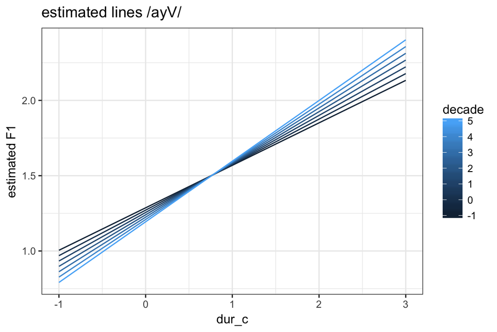

Next, we can look for the effects that interact with voicing:

```
                            Estimate Std. Error t value
plt_vclassay0              -0.061892   0.036771   -1.68
decade:plt_vclassay0       -0.098273   0.005434  -18.08
dur_c:plt_vclassay0        -0.078575   0.026847   -2.93
decade:dur_c:plt_vclassay0 -0.002469   0.004903   -0.50
```

These effects are saying that /ay0/ starts out with a lower F1, and has a steeper decline in F1 over decade (both unsurprising). It’s also saying that the duration effect on /ay0/ is *weaker* (i.e. 0.30 -0.08 = 0.22), and the steepening effect that (might) exist for /ayV/ is weaker (i.e. 0.020 - 0.002 = 0.018).

When I look at these results, it seems obvious to me that we need to be taking into account the effect of decade and duration. But, I don’t have a good prior hypotheses for some of these interactions. Specifically,

- I don’t know why the duration effect should get stronger over time.
- I don’t know why the duration effect should be weaker for /ay0/.
- I don’t know why the steepening effect should be weaker for /ay0/.

Looking at the three way interaction specifically, it has a very small effect size, and also a very small t value. Maybe it’s not contributing anything to the model. Let’s fit another model that is exactly the same, except it excludes that effect.

```r
ay_smaller_mod <- lmer(F1_n ~ decade * dur_c * plt_vclass -
                         decade:dur_c:plt_vclass +
                      (1 + dur_c * plt_vclass | idstring) +
                      (1 | word),
                    data = ay,
                    verbose = T)
```

```r
summary(ay_smaller_mod)
```

```
Linear mixed model fit by REML ['lmerMod']
Formula: F1_n ~ decade * dur_c * plt_vclass - decade:dur_c:plt_vclass +
    (1 + dur_c * plt_vclass | idstring) + (1 | word)
   Data: ay

REML criterion at convergence: 152849.2

Scaled residuals:
    Min      1Q  Median      3Q     Max
-5.6144 -0.5848 -0.0177  0.5644 11.5873

Random effects:
 Groups   Name                Variance Std.Dev. Corr
 word     (Intercept)         0.04093  0.2023
 idstring (Intercept)         0.01599  0.1265
          dur_c               0.01868  0.1367   -0.08
          plt_vclassay0       0.03693  0.1922   -0.58  0.03
          dur_c:plt_vclassay0 0.01358  0.1165    0.27 -0.75  0.09
 Residual                     0.34582  0.5881
Number of obs: 84713, groups:  word, 959; idstring, 326

Fixed effects:
                      Estimate Std. Error t value
(Intercept)           1.269826   0.020965   60.57
decade               -0.015196   0.003303   -4.60
dur_c                 0.306964   0.016712   18.37
plt_vclassay0        -0.062346   0.036760   -1.70
decade:dur_c          0.019048   0.003189    5.97
decade:plt_vclassay0 -0.098090   0.005422  -18.09
dur_c:plt_vclassay0  -0.090591   0.012350   -7.34

Correlation of Fixed Effects:
            (Intr) decade dur_c  plt_v0 dcd:d_ dcd:_0
decade      -0.700
dur_c       -0.050  0.010
plt_vclssy0 -0.544  0.373  0.069
decade:dr_c  0.006 -0.001 -0.846 -0.054
dcd:plt_vc0  0.403 -0.574 -0.086 -0.661  0.095
dr_c:plt_v0  0.070  0.018 -0.185 -0.053 -0.108  0.042
```

One way we could try to evaluate which of these models is better is just to compare their root mean squared error. In case you’re hazy on how to calculate the RMSE, here’s a step by step breakdown of the code:

[figure not shown]

We can calcualte this for both models:

```r
rmse_big <- sqrt(mean((ay$F1_n - fitted(ay_big_mod)) ^ 2))
rmse_smaller <- sqrt(mean((ay$F1_n - fitted(ay_smaller_mod)) ^ 2))
```

Then see which one is *smaller*.

```r
rmse_big < rmse_smaller
```

```
[1] TRUE
```

```r
rmse_smaller - rmse_big
```

```
[1] 2.545569e-06
```

The bigger model has a smaller RMSE (by a very little bit), meaning it is a better fit to the data. But is it *worth* having the additional ineraction parameter? It is almost always the case that *any* predictor you add to the data will improve the model fit to the data.

## Overfitting

Mixed effects models, just like all other models, can be subject to “overfitting”. Here’s a really obvious example involving different smoothing line to the pre-voiceless /ay/ data.

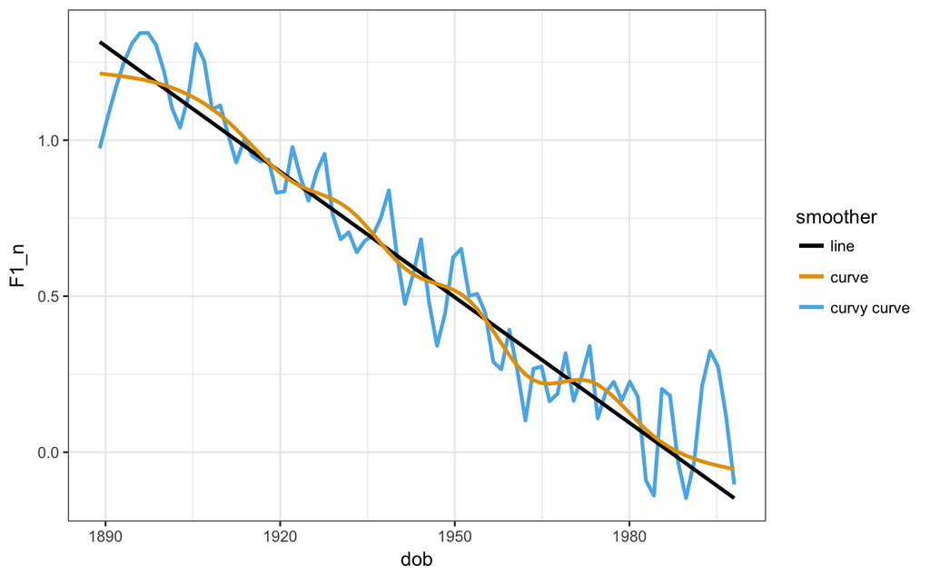

They’re all some attempt to “model” the data. The straight line abstracts away from a lot of the detailed movement in the data to describe it all as just a straignt line. The curve abstracts less, and captures more of the variation in the data. The curvy curve is chasing every little blip in the data.

In some sense, the curvy curve is a better *descrption* of the data, and it definiltey results in a smaller root mean squared error. But it’s not necessarilly a better *model* of the data, in a few senses.

1. By chasing fluctuations present in the *sample*, it will be less successful at predicting new observations from the *population*.
2. As a *model* of the phenomenon of interest, it is putting too much stock into minor fluctuations.

At the same time, you also don’t want a model that is *too* simple, because you’ll wind up overlooking important explanatory or predictive factors.

This is also sometimes called the *bias-variance tradeoff*. A model with *high bias* is too simple, and underfits the data. A model with *high variance* is too complex, and overfits the data.

## Model Comparison

The question we want to know is whether the additional complexity of the model is *worth* the improvement of the fit. There are a few approaches to making this kind of evaluation, which we’ll cover. For the time being, we’ll assume that we’re only comparing models that are *properly nested*. That is, one model has **all of the same predictors and random effects structures** as the other model, plus some. We can compare the goodness of fit of `ay_big_mod` and `ay_smaller_mod` using the `anova()` function. Now, when you use `anova()` on to LMEs, it is *not* doing an ANOVA. The function `anova()` has just become semantically bleached to mean “compare two models”.

```r
anova(ay_big_mod, ay_smaller_mod)
```

```
refitting model(s) with ML (instead of REML)
```

```
Data: ay
Models:
ay_smaller_mod: F1_n ~ decade * dur_c * plt_vclass - decade:dur_c:plt_vclass +
ay_smaller_mod:     (1 + dur_c * plt_vclass | idstring) + (1 | word)
ay_big_mod: F1_n ~ decade * dur_c * plt_vclass + (1 + dur_c * plt_vclass |
ay_big_mod:     idstring) + (1 | word)
               Df    AIC    BIC logLik deviance  Chisq Chi Df Pr(>Chisq)
ay_smaller_mod 19 152832 153009 -76397   152794
ay_big_mod     20 152834 153020 -76397   152794 0.2572      1      0.612
```

There’s a lot in here, let’s take it piece by piece:

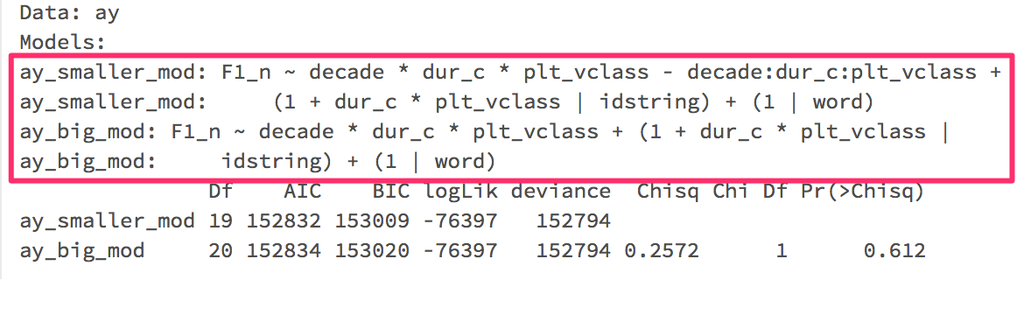

This is just a reminder of which models you’re comparing. R is clever enough to do the model comparison in the right order (the more complex model is compared to the simpler model.)

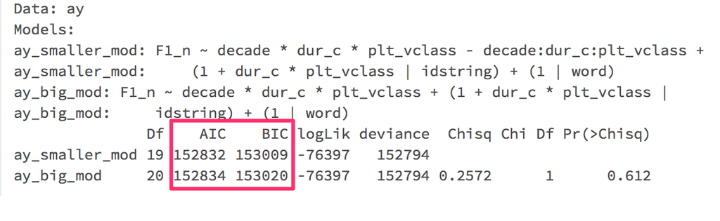

The AIC and the BIC are metrics of model fit. They’re trying to quantify this balance between how well the models fit the data vs how complex they are. I’ve mentioned the the tradeoff between improving the model fit and trying to avoid overfitting, and these *Information Criterions* are one way of trying to quantify it. I have the formulas for the AIC and the BIC here, not because the actual math matters for us, but in order to do a contrastive analysis:

$$AIC = 2k - 2\ln(\hat{L})$$

$$BIC = \ln(n)k - 2\ln(\hat{L})$$

This is a classic example of having two competing metrics that are basically the same, but people have their preferences so we get both.

When you’re comparing models (even multiple models) using AIC and BIC, the models with the *smallest* AIC and BIC are the preferred ones. There isn’t an established difference in AIC and BIC which is considered a “significant” difference. *Roughly* speaking, AIC and BIC differences around 2 indicated a weak difference between two models, and as the difference grows, so does the strength of the preference for the model with the smaller AIC and BIC.

As we can see from the actual AIC and BIC differences in our two models, the AIC difference is only 2, but the BIC difference is 11. I would conclude that this indicates a preference for the smaller model.

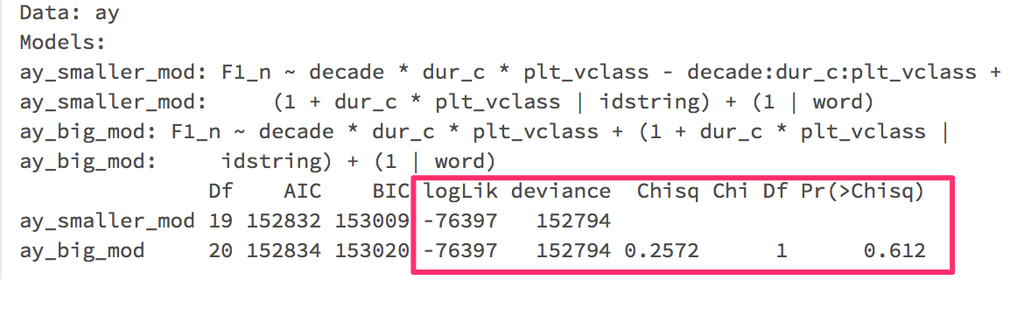

This block of numbers is dedicated to the Likelihood Ratio Test (or LRT). It is a significance test for whether the more complex model significantly improves model fit. Some notes:

- LRTs should only be carried out comparing “nested” models. That is, one model should have all the same parameters as the other, plus some.
- LRTs should ideally be carried out on minimally contrasting models.
- These are evaluating a “stepping up” of the model complexity.

## How to actually go about doing model comparison.

When doing model comparison, my recommendation is to do it in a directed way. For example, I’ve felt a little suspicious of this decade:duration interaction. So, I’ve fit a third model that also removes the two way interaction between duration and decade.

```r
ay_smaller_er_mod <- lmer(F1_n ~ decade * dur_c * plt_vclass -
                         decade:dur_c:plt_vclass -
                         decade:dur_c +
                      (1 + dur_c * plt_vclass | idstring) +
                      (1 | word),
                    data = ay,
                    verbose = T)
```

And now, we can compare all three models in one go:

```r
anova(ay_big_mod, ay_smaller_mod, ay_smaller_er_mod)
```

```
refitting model(s) with ML (instead of REML)
```

```
Data: ay
Models:
ay_smaller_er_mod: F1_n ~ decade * dur_c * plt_vclass - decade:dur_c:plt_vclass -
ay_smaller_er_mod:     decade:dur_c + (1 + dur_c * plt_vclass | idstring) + (1 |
ay_smaller_er_mod:     word)
ay_smaller_mod: F1_n ~ decade * dur_c * plt_vclass - decade:dur_c:plt_vclass +
ay_smaller_mod:     (1 + dur_c * plt_vclass | idstring) + (1 | word)
ay_big_mod: F1_n ~ decade * dur_c * plt_vclass + (1 + dur_c * plt_vclass |
ay_big_mod:     idstring) + (1 | word)
                  Df    AIC    BIC logLik deviance   Chisq Chi Df Pr(>Chisq)
ay_smaller_er_mod 18 152864 153032 -76414   152828
ay_smaller_mod    19 152832 153009 -76397   152794 33.7791      1  6.174e-09 ***
ay_big_mod        20 152834 153020 -76397   152794  0.2572      1      0.612
---
Signif. codes:  0 ‘***’ 0.001 ‘**’ 0.01 ‘*’ 0.05 ‘.’ 0.1 ‘ ’ 1
```

According to the Likelihood ratio test, the two way interaction significantly improves the model fit, but the three way interaction doesn’t. The model with the two way interaction is *strongly* preferred by the BIC and the AIC compared to the model without it, but only weakly over the model with the three way interaction.

There are methods out there that allow you to automate this process of adding and removing predictors to see which model is most preferred, but I would recommend you *not* use them. First of all, automated step-up, step-down model selection has fallen by the wayside within statistics proper. Second, you should always have a *reason* for doing some model comparison or another.

## Specifying models

When approaching how to build up a model (which predictors should be included or excluded), I would caution against “kitchen sink” models, or trying to trying to outsource your reasoning to an automated step-wise regression.

I’ll summarise Gelman & Hill’s (2006) recommendations here:

- “Include all input variables that, for substantive reasons, might be expected to be important in predicting the outcome.”
  - Joe addendum: I think substantive reasons include “I have a good theory” and “Previous work has included these”.
- “It is not always necessary to include these inputs as separate predictors-—for example, sometimes several inputs can be averaged or stunmed to create a ‘total score’ that can be used as a single predictor in the model.”
- “For inputs that have large effects, consider including their interactions as well.”

Their recommendation for excluding a variable from a model is more nuanced. They say:

- “If a predictor is not statistically significant and has the expected sign, it is generally fine to keep it in. It may not help predictions dramatically hut is also probably not hurting them.”
- “If a predictor is not statistically significant and does not have the expected sign (for example, incumbency having a negative effect on vote share), consider removing it from the model (that is, setting its coefilcient to zero).”
- “If a predictor is statistically significant and does not have the expected sign, then think hard if it makes sense.”
- “If a predictor is statistically significant and has the expected sign, then by all means keep it in the model.”

## Specifying a random effects structure

There is currently some debate about how to specify the random effects structure of mixed effects models. One proposal from [Barr et al (2013)](https://www.sciencedirect.com/science/article/pii/S0749596X12001180?via%3Dihub) is to always fit a “maximal” model. That is, a model where all possible random intercepts & slopes are included. You basically “set it and forget it” (unless the model doesn’t converge!) For example, for the /ay/ model we’ve settled on, the maximal random effects would look like this:

```r
ay_max_model <- lmer(F1_n ~ decade * dur_c +
                            dur_c * plt_vclass +
                            decade * plt_vclass +
                            (1 + dur_c * plt_vclass  | idstring) +
                            (1 + decade * dur_c | word),
                     data = ay,
                     verbose = T)
```

```r
summary(ay_max_model)
```

```
Linear mixed model fit by REML ['lmerMod']
Formula: F1_n ~ decade * dur_c + dur_c * plt_vclass + decade * plt_vclass +
    (1 + dur_c * plt_vclass | idstring) + (1 + decade * dur_c |      word)
   Data: ay

REML criterion at convergence: 152123.3

Scaled residuals:
    Min      1Q  Median      3Q     Max
-5.6622 -0.5845 -0.0168  0.5625 11.6500

Random effects:
 Groups   Name                Variance  Std.Dev. Corr
 word     (Intercept)         0.0583882 0.24164
          decade              0.0004440 0.02107  -0.32
          dur_c               0.0130406 0.11420  -0.78 -0.21
          decade:dur_c        0.0001845 0.01358   0.28  0.04 -0.34
 idstring (Intercept)         0.0155504 0.12470
          dur_c               0.0183532 0.13547  -0.08
          plt_vclassay0       0.0371061 0.19263  -0.58  0.04
          dur_c:plt_vclassay0 0.0131549 0.11469   0.26 -0.75  0.09
 Residual                     0.3419508 0.58477
Number of obs: 84713, groups:  word, 959; idstring, 326

Fixed effects:
                      Estimate Std. Error t value
(Intercept)           1.265448   0.025646   49.34
decade               -0.006180   0.004322   -1.43
dur_c                 0.272318   0.021726   12.53
plt_vclassay0        -0.101628   0.045008   -2.26
decade:dur_c          0.012676   0.003914    3.24
dur_c:plt_vclassay0  -0.036360   0.024906   -1.46
decade:plt_vclassay0 -0.096538   0.007482  -12.90

Correlation of Fixed Effects:
            (Intr) decade dur_c  plt_v0 dcd:d_ dr_:_0
decade      -0.732
dur_c       -0.309  0.073
plt_vclssy0 -0.542  0.387  0.157
decade:dr_c  0.107 -0.125 -0.746 -0.036
dr_c:plt_v0  0.219  0.009 -0.349 -0.301  0.006
dcd:plt_vc0  0.401 -0.548 -0.044 -0.733  0.075 -0.020
```

One thing to note about this model is that it took a *very* long time to fit.

There is another approach to specifying the random effects structure from [Bates et al (2015)](https://arxiv.org/abs/1506.04967) that we should be trying to fit *parsimionious* random effects structures.

For the time being, their recommended workflow is a little difficult to teach. The recommend installing their `RePsychLing` package to use the `rePCA()` function.

```r
devtools::install_github("dmbates/RePsychLing")
library(RePsychLing)
```

```r
summary(rePCA(ay_max_model))
```

```
$word
Importance of components%s:
                         [,1]    [,2]    [,3]    [,4]
Standard deviation     0.4406 0.11660 0.02168 0.02065
Proportion of Variance 0.9305 0.06516 0.00225 0.00204
Cumulative Proportion  0.9305 0.99570 0.99796 1.00000

$idstring
Importance of components%s:
                         [,1]   [,2]   [,3]    [,4]
Standard deviation     0.3581 0.2866 0.1672 0.08339
Proportion of Variance 0.5228 0.3349 0.1140 0.02835
Cumulative Proportion  0.5228 0.8576 0.9717 1.00000
```

The important line to look at in each of these summaries of `word` and `idstring` is the `Cumulative Proportion`. If that reaches a value of 1 before the final column, it suggests there is too much structure to your random effects, but it doesn’t tell you *what* to make simpler.

But, a good place to start wold probably be the random effect with the smallest standard deviation, which in the maximal model is the interaction between decade and duration.

```r
ay_less_max_model <- lmer(F1_n ~ decade * dur_c +
                            dur_c * plt_vclass +
                            decade * plt_vclass +
                            (1 + dur_c * plt_vclass  | idstring) +
                            (1 + decade + dur_c | word),
                     data = ay,
                     verbose = T)
```

```r
anova(ay_less_max_model,
      ay_max_model)
```

```
Data: ay
Models:
ay_less_max_model: F1_n ~ decade * dur_c + dur_c * plt_vclass + decade * plt_vclass +
ay_less_max_model:     (1 + dur_c * plt_vclass | idstring) + (1 + decade + dur_c |
ay_less_max_model:     word)
ay_max_model: F1_n ~ decade * dur_c + dur_c * plt_vclass + decade * plt_vclass +
ay_max_model:     (1 + dur_c * plt_vclass | idstring) + (1 + decade * dur_c |
ay_max_model:     word)
                  Df    AIC    BIC logLik deviance  Chisq Chi Df Pr(>Chisq)
ay_less_max_model 24 152145 152369 -76048   152097
ay_max_model      28 152128 152390 -76036   152072 24.678      4   5.84e-05 ***
---
Signif. codes:  0 ‘***’ 0.001 ‘**’ 0.01 ‘*’ 0.05 ‘.’ 0.1 ‘ ’ 1
```

In this case, both the AIC and the Likelihood Ratio Test seem to prefer the maximal model (with the BIC frustratingly prefering the less than maximal model).

# Quantifying reliability of the estimates

Let’s come back to a simple model of /ay/ raising.

```r
summary(ayT_simple_mod)
```

```
Linear mixed model fit by REML ['lmerMod']
Formula: F1_n ~ decade * dur_c + (dur_c | idstring) + (1 | word)
   Data: ayT

REML criterion at convergence: 26273.6

Scaled residuals:
    Min      1Q  Median      3Q     Max
-6.1063 -0.5875 -0.0404  0.5350 10.2417

Random effects:
 Groups   Name        Variance Std.Dev. Corr
 idstring (Intercept) 0.02943  0.1716
          dur_c       0.01638  0.1280   0.29
 word     (Intercept) 0.06139  0.2478
 Residual             0.21475  0.4634
Number of obs: 19342, groups:  idstring, 326; word, 255

Fixed effects:
              Estimate Std. Error t value
(Intercept)   1.216774   0.031948   38.09
decade       -0.114033   0.004638  -24.59
dur_c         0.221240   0.023976    9.23
decade:dur_c  0.018724   0.004485    4.17

Correlation of Fixed Effects:
            (Intr) decade dur_c
decade      -0.649
dur_c        0.109 -0.163
decade:dr_c -0.120  0.210 -0.890
```

## The Bootstrap

If you want to get something p-value-like or confidence interval-like for the parameters in a mixed effects model, the people who have developed these techniques recommend *bootstrapping*. Bootstrapping is a very general purpose technique that sort of looks like it shouldn’t work.

### Bootstrapping in Principle

*Bootstrapping* is a very general method for estimating our uncertainty about any given paremeter estimate. For example, let’s say that we had 8 randomly[^1] sampled heights of linguists in a class I taught, and we were interested in how noisy an estimate this is of the average height of linguists.

```r
heights = c(a = 69, b = 75, c = 62, d = 62, e = 73, f = 71, g = 61, h = 64)
mean(heights)
```

```
[1] 67.125
```

One method statisticians have developed is the “bootstrap” estimate of uncertainty. The way that works is you first resample your sample, with replacement.

```r
new_heights = sample(heights, replace = T)
new_heights
```

```
 b  h  h  h  a  h  c  d
75 64 64 64 69 64 62 62
```

Some people’s heights have shown up more than once, and some none at all. Then, you take the mean

```r
mean(new_heights)
```

```
[1] 65.5
```

And now, you do this hundreds and hundreds of times.

```r
replicates <- (1:100000) %>%
                map(~sample(heights, replace = T))%>%
                map(mean)%>%
                simplify()
```

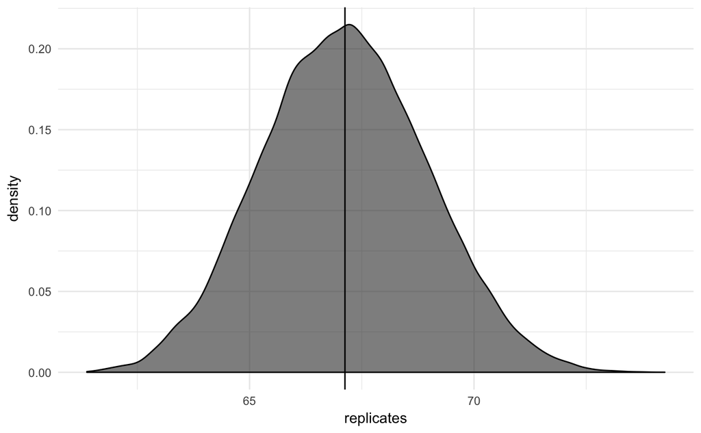

```r
data_frame(replicates = replicates)%>%
  ggplot(aes(replicates))+
    stat_density(color = "black", alpha = 0.6)+
    geom_vline(xintercept = mean(heights))+
    theme_minimal()
```

The statisticians have set unto us that this is a sensible way to estimate uncertainty about the mean of our sample. As the bootstrap is to the sample, so the sample is to the population. We can use some very simplistic methods to get a confidence interval out of the boostraps, say by taking the center 95% interval from the sample:

```r
quantile(replicates, prob = c(0.025, 0.975))
```

```
  2.5%  97.5%
63.625 70.750
```

```r
sort(heights)
```

```
 g  c  d  h  a  f  e  b
61 62 62 64 69 71 73 75
```

You can use bootstrap replication for any property of the sample, incidentally. For example, we could try to estimate the standard deviation of linguists’ heights using this method.

```r
sd_replicates <- (1:100000) %>%
                map(~sample(heights, replace = T))%>%
                map(sd)%>%
                simplify()
```

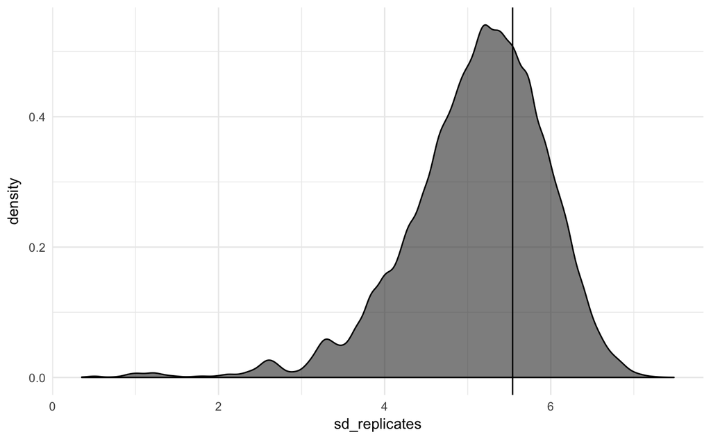

```r
data_frame(sd_replicates = sd_replicates)%>%
  ggplot(aes(sd_replicates))+
    stat_density(color = "black", alpha = 0.6)+
    geom_vline(xintercept = sd(heights))+
    theme_minimal()
```

### Bootstrapping for Regression

**NOTE!**: I give a bunch of code to do bootstrap replication by hand here, but there is a pre-built function to use called `bootMer()`.

Bootstrapping to get confidence intervals for regression paremeters works in a similar way, but implemented differently. For clarity’s sake, we’ll just look at the data from one speaker.

```r
sp1 <- ay %>%
          filter(idstring == idstring[1], plt_vclass == "ay") %>%
          select(F1_n, dur_c)
```

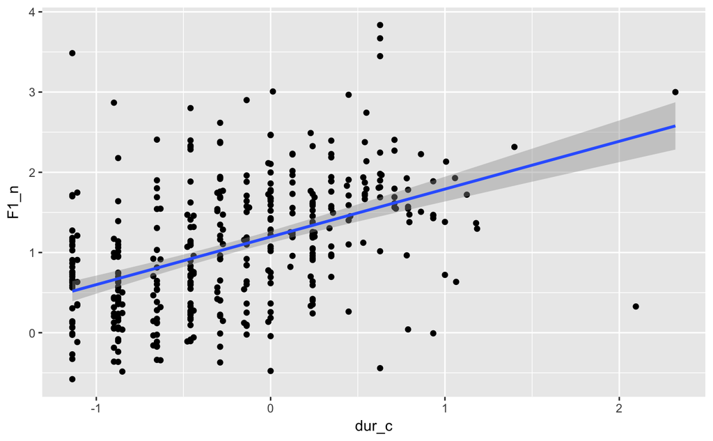

```r
ggplot(sp1, aes(dur_c, F1_n))+
    geom_point()+
    stat_smooth(method = 'lm')
```

```r
sp1_mod <- lm(F1_n ~ dur_c, data = sp1)
sp1_mod
```

```
Call:
lm(formula = F1_n ~ dur_c, data = sp1)

Coefficients:
(Intercept)        dur_c
     1.1950       0.5956
```

With this model, every data point has three values associated with it:

1. Its x value (in this case, its duration)
2. Its fitted y value (in this case, its predicted F1)
3. Its residual error (the difference between its observed F1 and and the predicted F1).

In order to get a bootstrap estimate of the intercept and slope here, you actually sample the residuals with replacement, add them to each point’s fitted value, and refit the model.

```r
sp1$resid <- resid(sp1_mod)
sp1$fitted <- fitted(sp1_mod)
head(sp1)
```

|  | F1_n | dur_c | resid | fitted |
| --- | --- | --- | --- | --- |
| 1 | 1.6906955 | 0.7104934 | 0.07255542 | 1.6181401 |
| 2 | 1.8716322 | 0.5405684 | 0.35470418 | 1.5169281 |
| 3 | 1.2851476 | -0.2735651 | 0.25313981 | 1.0320078 |
| 4 | 1.5209893 | 0.0000000 | 0.32603863 | 1.1949507 |
| 5 | 0.8970694 | -0.4594316 | -0.02423110 | 0.9213006 |
| 6 | 1.7593267 | -0.2895066 | 0.73681412 | 1.0225126 |

As a reminder, here’s a plot of the observed duration values against the fitted F1 values.

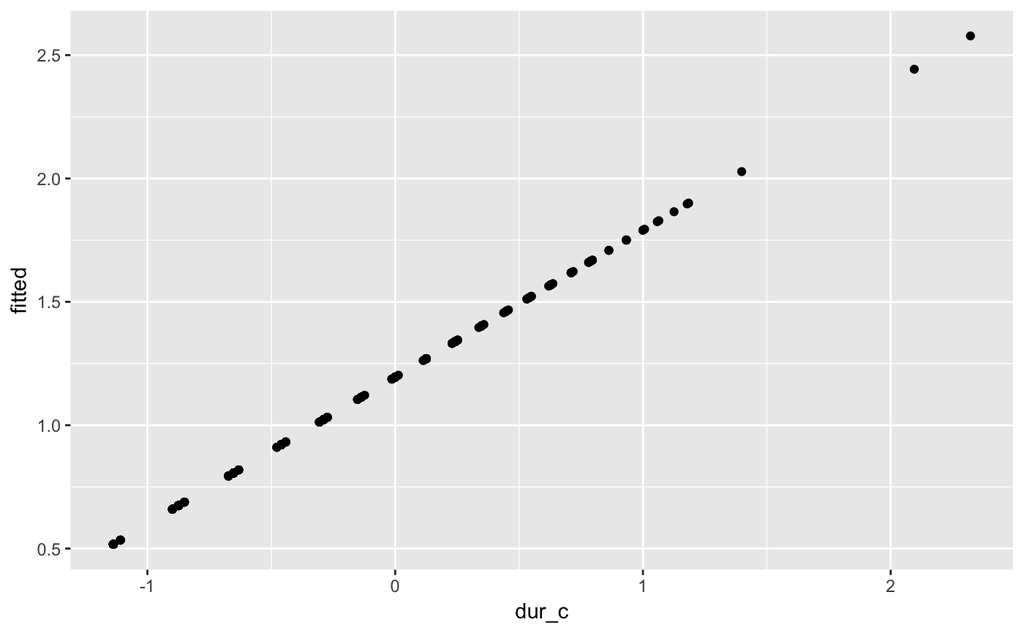

```r
ggplot(sp1, aes(dur_c, fitted))+
    geom_point()
```

To get back the original data, you need to add each data point’s residual error to the fitted value.

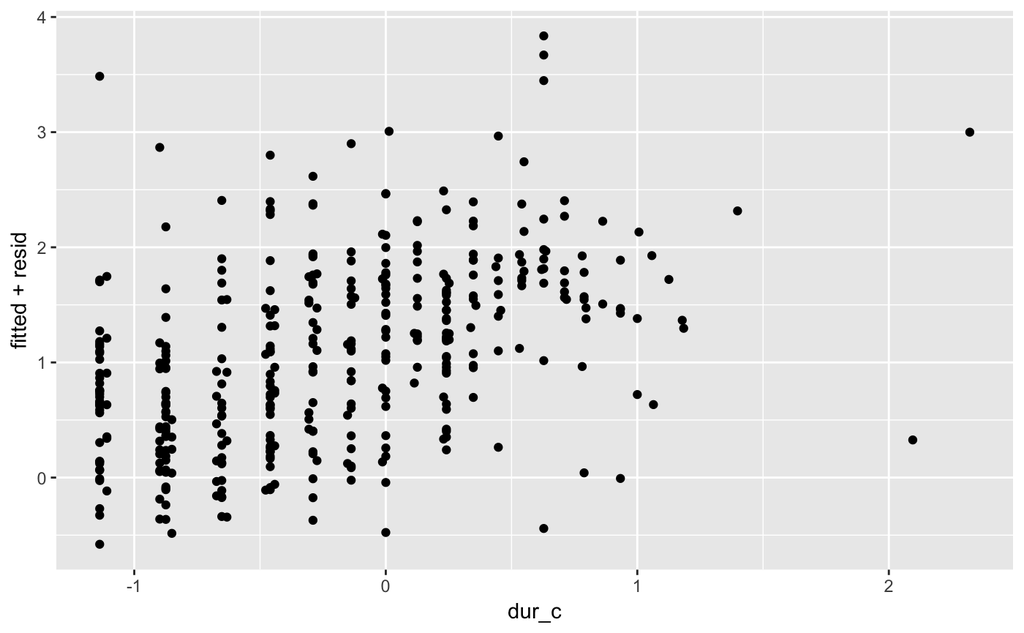

```r
ggplot(sp1, aes(dur_c, fitted + resid))+
    geom_point()
```

In bootstrapping, you actually create a new set of residuals by sampling the existing residuals with replacement. Then you add these to the fitted values to get a new bootstrap replicate.

Now, we just need to collect up all of these re-fittings, and plot them.

```r
lm_boot <- (1:1000)%>%
                map(~(sp1 %>% mutate(resid_samp = sample(resid, replace = T),
                                     F1_n = resid_samp + fitted)))%>%
                map(~(lm(F1_n ~ dur_c, data = .x)))%>%
                map(tidy)%>%
                bind_rows(.id = "id")
```

[figure not shown]

```r
lm_boot %>%
  ggplot(aes(estimate))+
    stat_density(alpha = 0.6, color = "black")+
    facet_wrap(~term, scales = "free")+
    geom_vline(xintercept = 0)+
    theme_bw()
```

### Bootstrapping LMEs

The specific way which boostrapping works for `lmer` models is different than for vanilla linear models (dealing with the random effects structure appropriately is complex), but fortunately we don’t need to write code to do that for us. The function `bootMer()` will do it for us.

bootMer(model, FUN = fixef, nsim, …)

- `model`
  - the model you want to do bootstrapping on (can be a linear or other generalized linear mixed effects model).
- `FUN`
  - The function you want to apply to each re-fit model. This will almost always be just `fixef`
- `nsim`
  - The number of bootstrap simulations you want to do
- `...`
  - Additional optional arguments (e.g. what different kinds of bootstrapping you want to do, whether or not to use parallel processing).

~5 minute break

Run this code to do 5 bootstrap replications

```r
ayT_bootstraps <- bootMer(ayT_simple_mod,
                         FUN = fixef,
                         nsim = 5,
                         verbose = T)
```

The somewhat annoying thing about bootstrapping is that it takes just as long to fit each replication as it does to fit the original model.

```r
ayT_bootstraps <- bootMer(ayT_simple_mod,
                          FUN = fixef,
                          nsim = 5000,
                          verbose = T)
```

```r
ayT_bootstraps
```

```
PARAMETRIC BOOTSTRAP


Call:
bootMer(x = ayT_simple_mod, FUN = fixef, nsim = 5000, verbose = T)


Bootstrap Statistics :
       original        bias    std. error
t1*  1.21677373 -5.647136e-04 0.031775509
t2* -0.11403289 -2.920779e-05 0.004597193
t3*  0.22123967 -5.125492e-05 0.023772427
t4*  0.01872352 -2.233928e-05 0.004390556
```

Each `t*` item corresponds to a fixed effect coefficient. They show up in the summary in the same order they did in the model summary:

```r
fixef(ayT_simple_mod)
```

```
 (Intercept)       decade        dur_c decade:dur_c
  1.21677373  -0.11403289   0.22123967   0.01872352
```

In the bootstrap summary, the `original` column corresponds to the original coefficient estimate from the model.

To get a confidence interval for these parameters, we need to use the `boot.ci()` function.

boot.ci(bootstrap, index, type = perc)

- `bootstrap`
  - The bootstrap object
- `index`
  - The index of the coefficient you want a confidence interval for
- `type`
  - Unfortunately, there are many different ways of estimating a confidence interval from bootstrapped replicates, and not all of them work for a bootstrapped lme. I recommend `type = "perc"`

So to get the bootstrap confidence interval for the intercept, we’d give `index=1`.

```r
boot.ci(ayT_bootstraps, index = 1, type = "perc")
```

```
BOOTSTRAP CONFIDENCE INTERVAL CALCULATIONS
Based on 5000 bootstrap replicates

CALL :
boot.ci(boot.out = ayT_bootstraps, type = "perc", index = 1)

Intervals :
Level     Percentile
95%   ( 1.154,  1.277 )
Calculations and Intervals on Original Scale
```

This confidence interval excludes 0, so we could call this a reliable effect.

To get the confidence interval for the interaction between duration and decade, you give it `index = 4`

```r
boot.ci(ayT_bootstraps, index = 4, type = "perc")
```

```
BOOTSTRAP CONFIDENCE INTERVAL CALCULATIONS
Based on 5000 bootstrap replicates

CALL :
boot.ci(boot.out = ayT_bootstraps, type = "perc", index = 4)

Intervals :
Level     Percentile
95%   ( 0.0101,  0.0276 )
Calculations and Intervals on Original Scale
```

This confidence interval also excludes 0.

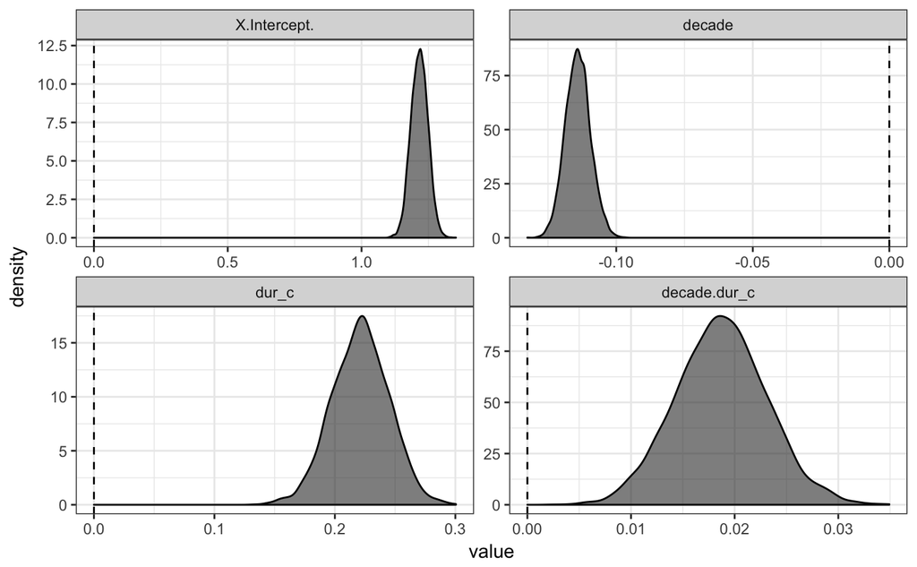

```r
ayT_bootstraps$t %>%
  data.frame()%>%
  gather()%>%
  mutate(key = factor(key, levels = c("X.Intercept.", "decade","dur_c","decade.dur_c")))%>%
  ggplot(aes(value))+
    stat_density(alpha = 0.6, color = "black")+
    geom_vline(xintercept = 0, linetype = 2)+
    facet_wrap(~key, scales = "free")+
    theme_bw()
```

## P-values with `lmeTtest`

If you are ever stuck with a reviewer who demands p-values, there is a package, `lmerTest` that will provide pvalues in the summary of models. What it specifically does is use the Satterthwaite approximation to estimate the degrees of freedom.

```r
library(lmerTest)
```

```r
ayT_simple_mod_p <- lmer(F1_n ~ decade*dur_c +
                         (dur_c | idstring) +
                         (1|word),
                       data = ayT)
```

```r
summary(ayT_simple_mod_p)
```

```
Linear mixed model fit by REML t-tests use Satterthwaite approximations to degrees of freedom [lmerMod
]
Formula: F1_n ~ decade * dur_c + (dur_c | idstring) + (1 | word)
   Data: ayT

REML criterion at convergence: 26273.6

Scaled residuals:
    Min      1Q  Median      3Q     Max
-6.1063 -0.5875 -0.0404  0.5350 10.2417

Random effects:
 Groups   Name        Variance Std.Dev. Corr
 idstring (Intercept) 0.02943  0.1716
          dur_c       0.01638  0.1280   0.29
 word     (Intercept) 0.06139  0.2478
 Residual             0.21475  0.4634
Number of obs: 19342, groups:  idstring, 326; word, 255

Fixed effects:
               Estimate Std. Error         df t value Pr(>|t|)
(Intercept)    1.216774   0.031948 403.200000  38.087  < 2e-16 ***
decade        -0.114033   0.004638 300.200000 -24.585  < 2e-16 ***
dur_c          0.221240   0.023976 302.400000   9.228  < 2e-16 ***
decade:dur_c   0.018724   0.004485 232.000000   4.175 4.22e-05 ***
---
Signif. codes:  0 ‘***’ 0.001 ‘**’ 0.01 ‘*’ 0.05 ‘.’ 0.1 ‘ ’ 1

Correlation of Fixed Effects:
            (Intr) decade dur_c
decade      -0.649
dur_c        0.109 -0.163
decade:dr_c -0.120  0.210 -0.890
```

[^1]: In this case, not actually random.